# Analysis of student's time spending habits slides

Title: Student Spending Habits Dataset Description: This dataset contains fictional data representing the spending habits of 1000 students across various demographic groups and academic backgrounds. The dataset includes information such as age, gender, year in school, major, monthly income, financial aid received, and expenses in different spending categories. Spending categories include tuition, housing, food, transportation, books & supplies, entertainment, personal care, technology, health & wellness, and miscellaneous expenses. Additionally, the dataset includes the preferred payment method for each student. Columns:

Age: Age of the student (in years) Gender: Gender of the student (Male, Female, Non-binary) Year in School: Year of study (Freshman, Sophomore, Junior, Senior) Major: Field of study or major Monthly Income: Monthly income of the student (in dollars) Financial Aid: Financial aid received by the student (in dollars) Tuition: Expenses for tuition (in dollars) Housing: Expenses for housing (in dollars) Food: Expenses for food (in dollars) Transportation: Expenses for transportation (in dollars) Books & Supplies: Expenses for books and supplies (in dollars) Entertainment: Expenses for entertainment (in dollars) Personal Care: Expenses for personal care items (in dollars) Technology: Expenses for technology (in dollars) Health & Wellness: Expenses for health and wellness (in dollars) Miscellaneous: Miscellaneous expenses (in dollars) Preferred Payment Method: Preferred payment method (Cash, Credit/Debit Card, Mobile Payment App) Usage: This dataset can be used for various analyses related to student spending habits, financial literacy, budgeting strategies, and payment preferences. Researchers, educators, and students can utilize this dataset for exploratory data analysis, predictive modeling, and developing insights into the financial behaviors of students. Acknowledgements: This dataset was generated for educational and research purposes, and all data is entirely fictional.

License Apache 2.0

Expected update frequency Annually

Tags

Education

```python
import numpy as np  # Unleashing numerical wizardry
import seaborn as sns  # Crafting beautiful data visual symphonies
import pandas as pd  # Mastering the art of data manipulation
import matplotlib.pyplot as plt  # Painting data stories on a visual canvas
import warnings
warnings.simplefilter(action='ignore', category=FutureWarning)
```

Time to dive into the data! Reading our dataset using Pandas 🐼

```python
data = pd.read_csv("student_spending (1).csv")
```

# To safeguard our original data consistently creating a duplicate copy is crucial This precaution ensures that even in worst-case scenarios our original data remains untouched👌

```python
from copy import deepcopy  # Importing deepcopy for creating independent copies of nested objects
```

```python
df = deepcopy(data) # Summoning the data duplication spell for a perfect copy
```

With the fundamental libraries imported and our data ready for analysis, we are set to embark on our analytical journey. However, before delving in, a pivotal step awaits — comprehending the essence of our data and articulating our goals. To facilitate this process, we will employ CoNVO thinking, which breaks down into:

# exploratery data analysis

```python
df.head(10)
```

|  | Unnamed: 0 | age | gender | year_in_school | major | monthly_income | financial_aid | tuition | housing | food | transportation | books_supplies | entertainment | personal_care | technology | health_wellness | miscellaneous | preferred_payment_method |
| --- | --- | --- | --- | --- | --- | --- | --- | --- | --- | --- | --- | --- | --- | --- | --- | --- | --- | --- |
| 0 | 0 | 19 | Non-binary | Freshman | Psychology | 958 | 270 | 5939 | 709 | 296 | 123 | 188 | 41 | 78 | 134 | 127 | 72 | Credit/Debit Card |
| 1 | 1 | 24 | Female | Junior | Economics | 1006 | 875 | 4908 | 557 | 365 | 85 | 252 | 74 | 92 | 226 | 129 | 68 | Credit/Debit Card |
| 2 | 2 | 24 | Non-binary | Junior | Economics | 734 | 928 | 3051 | 666 | 220 | 137 | 99 | 130 | 23 | 239 | 112 | 133 | Cash |
| 3 | 3 | 23 | Female | Senior | Computer Science | 617 | 265 | 4935 | 652 | 289 | 114 | 223 | 99 | 30 | 163 | 105 | 55 | Mobile Payment App |
| 4 | 4 | 20 | Female | Senior | Computer Science | 810 | 522 | 3887 | 825 | 372 | 168 | 194 | 48 | 71 | 88 | 71 | 104 | Credit/Debit Card |
| 5 | 5 | 25 | Non-binary | Sophomore | Computer Science | 523 | 790 | 3151 | 413 | 386 | 122 | 131 | 73 | 38 | 234 | 108 | 99 | Mobile Payment App |
| 6 | 6 | 23 | Female | Freshman | Engineering | 1354 | 69 | 4973 | 812 | 398 | 101 | 213 | 21 | 38 | 157 | 117 | 48 | Credit/Debit Card |
| 7 | 7 | 23 | Female | Junior | Economics | 631 | 748 | 3966 | 571 | 269 | 92 | 251 | 37 | 90 | 152 | 56 | 62 | Mobile Payment App |
| 8 | 8 | 22 | Non-binary | Senior | Computer Science | 1402 | 248 | 5638 | 599 | 354 | 82 | 155 | 123 | 41 | 162 | 172 | 194 | Credit/Debit Card |
| 9 | 9 | 18 | Female | Junior | Computer Science | 1423 | 74 | 3977 | 626 | 249 | 117 | 123 | 51 | 74 | 243 | 34 | 196 | Mobile Payment App |

With the fundamental libraries imported and our data ready for analysis, we are set to embark on our analytical journey. However, before delving in, a pivotal step awaits — comprehending the essence of our data and articulating our goals. To facilitate this process, we will employ CoNVO thinking, which breaks down into:

Context Need Vision Outcome Much like any well-crafted story, our project scope mirrors a narrative structure. It unfolds with an exposition, representing the ( context ), introduces conflict as the ( need ), outlines a resolution as the ( vision ).

```python
df.columns
```

```
Index(['Unnamed: 0', 'age', 'gender', 'year_in_school', 'major',
       'monthly_income', 'financial_aid', 'tuition', 'housing', 'food',
       'transportation', 'books_supplies', 'entertainment', 'personal_care',
       'technology', 'health_wellness', 'miscellaneous',
       'preferred_payment_method'],
      dtype='object')
```

```python
del df['Unnamed: 0']
```

```python
df.isna() .sum()
```

```
age                         0
gender                      0
year_in_school              0
major                       0
monthly_income              0
financial_aid               0
tuition                     0
housing                     0
food                        0
transportation              0
books_supplies              0
entertainment               0
personal_care               0
technology                  0
health_wellness             0
miscellaneous               0
preferred_payment_method    0
dtype: int64
```

```python
df.duplicated() .sum()
```

```
0
```

```python
from scipy import stats
```

# choosing IQR over Z-score ,this method is favoured for outliers detections.

```python
# Hunting for outliers

numeric_columns = ['age', 'monthly_income', 'financial_aid', 'tuition', 'housing', 'food',
                    'transportation', 'books_supplies', 'entertainment', 'personal_care',
                    'technology', 'health_wellness', 'miscellaneous']

# IQR method
Q1 = df[numeric_columns].quantile(0.25)
Q3 = df[numeric_columns].quantile(0.75)
IQR = Q3 - Q1
outliers_iqr = ((df[numeric_columns] < (Q1 - 1.5 * IQR)) | (df[numeric_columns] > (Q3 + 1.5 * IQR)))

# Displaying the outliers
print("\nOutliers (IQR Method):")
print(outliers_iqr.sum())
print("\nNo magical outliers detected! Our data enchantment is working its wonders. 🪄🌟")
```

```
Outliers (IQR Method):
age                0
monthly_income     0
financial_aid      0
tuition            0
housing            0
food               0
transportation     0
books_supplies     0
entertainment      0
personal_care      0
technology         0
health_wellness    0
miscellaneous      0
dtype: int64

No magical outliers detected! Our data enchantment is working its wonders. 🪄🌟
```

```python
df. info()
```

```
<class 'pandas.core.frame.DataFrame'>
RangeIndex: 1000 entries, 0 to 999
Data columns (total 17 columns):
 #   Column                    Non-Null Count  Dtype
---  ------                    --------------  -----
 0   age                       1000 non-null   int64
 1   gender                    1000 non-null   object
 2   year_in_school            1000 non-null   object
 3   major                     1000 non-null   object
 4   monthly_income            1000 non-null   int64
 5   financial_aid             1000 non-null   int64
 6   tuition                   1000 non-null   int64
 7   housing                   1000 non-null   int64
 8   food                      1000 non-null   int64
 9   transportation            1000 non-null   int64
 10  books_supplies            1000 non-null   int64
 11  entertainment             1000 non-null   int64
 12  personal_care             1000 non-null   int64
 13  technology                1000 non-null   int64
 14  health_wellness           1000 non-null   int64
 15  miscellaneous             1000 non-null   int64
 16  preferred_payment_method  1000 non-null   object
dtypes: int64(13), object(4)
memory usage: 132.9+ KB
```

```python
df.info()
```

```
<class 'pandas.core.frame.DataFrame'>
RangeIndex: 1000 entries, 0 to 999
Data columns (total 17 columns):
 #   Column                    Non-Null Count  Dtype
---  ------                    --------------  -----
 0   age                       1000 non-null   int64
 1   gender                    1000 non-null   object
 2   year_in_school            1000 non-null   object
 3   major                     1000 non-null   object
 4   monthly_income            1000 non-null   int64
 5   financial_aid             1000 non-null   int64
 6   tuition                   1000 non-null   int64
 7   housing                   1000 non-null   int64
 8   food                      1000 non-null   int64
 9   transportation            1000 non-null   int64
 10  books_supplies            1000 non-null   int64
 11  entertainment             1000 non-null   int64
 12  personal_care             1000 non-null   int64
 13  technology                1000 non-null   int64
 14  health_wellness           1000 non-null   int64
 15  miscellaneous             1000 non-null   int64
 16  preferred_payment_method  1000 non-null   object
dtypes: int64(13), object(4)
memory usage: 132.9+ KB
```

```python
from tabulate import tabulate

def column_info_table(df):
    # Create a DataFrame with column information
    table_df = pd.DataFrame({
        'Column Name': df.columns,
        'Data Type': df.dtypes.values,
        'Number of Unique Values': df.nunique().values,
        'Unique Values': [df[column].unique()[:5] for column in df.columns]
    })

    return table_df

# Assuming df is your DataFrame
result_table = column_info_table(df)

# Display the table using tabulate
print(tabulate(result_table, headers='keys', tablefmt='pretty'))
```

```
+----+--------------------------+-----------+-------------------------+-----------------------------------------------------------------------+
|    |       Column Name        | Data Type | Number of Unique Values |                             Unique Values                             |
+----+--------------------------+-----------+-------------------------+-----------------------------------------------------------------------+
| 0  |           age            |   int64   |            8            |                           [19 24 23 20 25]                            |
| 1  |          gender          |  object   |            3            |                    ['Non-binary' 'Female' 'Male']                     |
| 2  |      year_in_school      |  object   |            4            |              ['Freshman' 'Junior' 'Senior' 'Sophomore']               |
| 3  |          major           |  object   |            5            | ['Psychology' 'Economics' 'Computer Science' 'Engineering' 'Biology'] |
| 4  |      monthly_income      |   int64   |           619           |                      [ 958 1006  734  617  810]                       |
| 5  |      financial_aid       |   int64   |           627           |                         [270 875 928 265 522]                         |
| 6  |         tuition          |   int64   |           838           |                      [5939 4908 3051 4935 3887]                       |
| 7  |         housing          |   int64   |           501           |                         [709 557 666 652 825]                         |
| 8  |           food           |   int64   |           290           |                         [296 365 220 289 372]                         |
| 9  |      transportation      |   int64   |           151           |                         [123  85 137 114 168]                         |
| 10 |      books_supplies      |   int64   |           244           |                         [188 252  99 223 194]                         |
| 11 |      entertainment       |   int64   |           131           |                         [ 41  74 130  99  48]                         |
| 12 |      personal_care       |   int64   |           81            |                           [78 92 23 30 71]                            |
| 13 |        technology        |   int64   |           248           |                         [134 226 239 163  88]                         |
| 14 |     health_wellness      |   int64   |           171           |                         [127 129 112 105  71]                         |
| 15 |      miscellaneous       |   int64   |           180           |                         [ 72  68 133  55 104]                         |
| 16 | preferred_payment_method |  object   |            3            |           ['Credit/Debit Card' 'Cash' 'Mobile Payment App']           |
+----+--------------------------+-----------+-------------------------+-----------------------------------------------------------------------+
```

When you delve into the magic of scheduling, a detailed panorama unfolds. Each column, its data type, unique values, and data snippet are elegantly designed – a captivating presentation. 🪄

On this board, there are 3 unique gender values, academic years host 4 fatigue levels, majors unfold in 5 different forms, and payment methods offer three options – all of which are seamlessly highlighted from the table.

A quick glance reveals columns representing student expenses, each important to our ultimate goal. The numerical range across each type of expenditure paints a diverse picture of student spending patterns. 📊

```python
df.describe() . T
```

|  | count | mean | std | min | 25% | 50% | 75% | max |
| --- | --- | --- | --- | --- | --- | --- | --- | --- |
| age | 1000.0 | 21.675 | 2.322664 | 18.0 | 20.00 | 22.0 | 24.00 | 25.0 |
| monthly_income | 1000.0 | 1020.650 | 293.841161 | 501.0 | 770.75 | 1021.0 | 1288.25 | 1500.0 |
| financial_aid | 1000.0 | 504.771 | 287.092575 | 0.0 | 261.00 | 513.0 | 751.50 | 1000.0 |
| tuition | 1000.0 | 4520.395 | 860.657944 | 3003.0 | 3779.75 | 4547.5 | 5285.00 | 6000.0 |
| housing | 1000.0 | 696.006 | 171.218620 | 401.0 | 538.75 | 704.5 | 837.25 | 1000.0 |
| food | 1000.0 | 252.642 | 86.949606 | 100.0 | 175.00 | 255.0 | 330.00 | 400.0 |
| transportation | 1000.0 | 124.637 | 43.557990 | 50.0 | 88.00 | 123.0 | 162.25 | 200.0 |
| books_supplies | 1000.0 | 174.761 | 72.404518 | 50.0 | 112.00 | 175.0 | 238.00 | 300.0 |
| entertainment | 1000.0 | 84.814 | 37.970451 | 20.0 | 54.00 | 86.0 | 116.00 | 150.0 |
| personal_care | 1000.0 | 60.699 | 22.898007 | 20.0 | 41.00 | 62.0 | 80.00 | 100.0 |
| technology | 1000.0 | 178.304 | 71.744441 | 50.0 | 114.00 | 178.0 | 241.00 | 300.0 |
| health_wellness | 1000.0 | 114.310 | 49.591544 | 30.0 | 73.00 | 115.0 | 158.00 | 200.0 |
| miscellaneous | 1000.0 | 108.910 | 52.412221 | 20.0 | 63.75 | 110.0 | 153.00 | 200.0 |

Bravo! As we delve into the details, our average age stands at 21 years, ranging from the youngest at 18 to the eldest at 25. The pattern continues—monthly income averages at 1,020 dollars, with the highest earner reaching 1,500 dollars. This storytelling repeats across all expense categories, offering a comprehensive view of our dataset. 📊👀

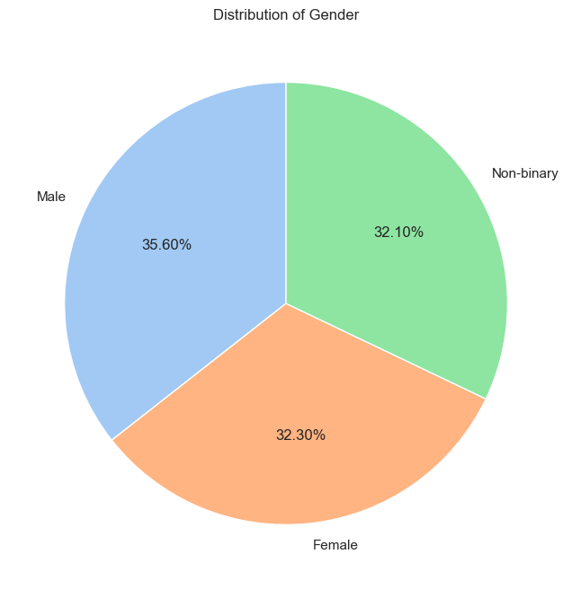

```python
# Set the style
sns.set(style="whitegrid")

# Create a pie chart for 'gender'
fig, ax = plt.subplots(figsize=(8, 8))
ax.pie(df['gender'].value_counts(), labels=df['gender'].value_counts().index, autopct='%1.2f%%', colors=sns.color_palette('pastel'), startangle=90)

# Set plot title
ax.set_title('Distribution of Gender')

# Display the plot
plt.show()
```

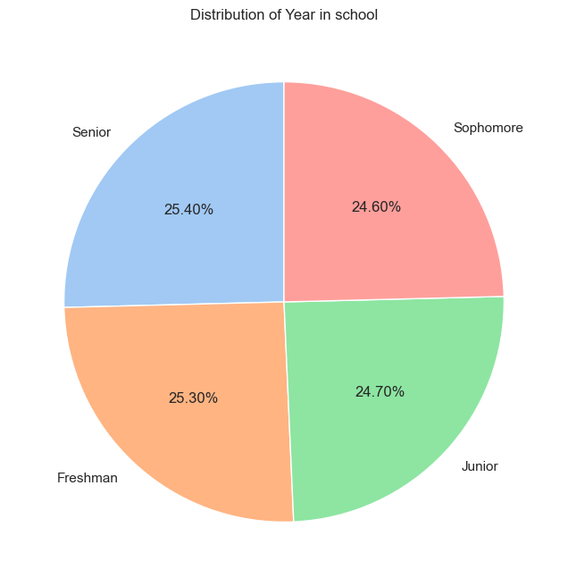

```python
# Set the style
sns.set(style="whitegrid")

# Create a pie chart for 'year_in_school'
fig, ax = plt.subplots(figsize=(8, 8))
ax.pie(df['year_in_school'].value_counts(), labels=df['year_in_school'].value_counts().index, autopct='%1.2f%%', colors=sns.color_palette('pastel'), startangle=90)

# Set plot title
ax.set_title('Distribution of Year in school')

# Display the plot
plt.show()
```

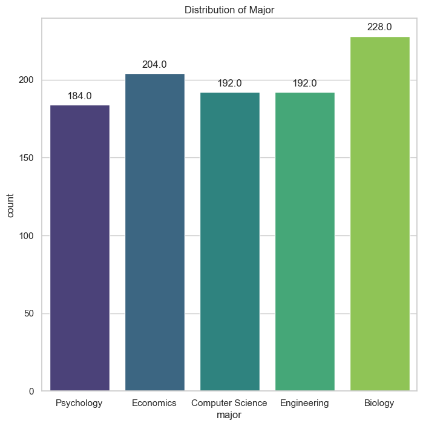

```python
# Set the style
sns.set(style="whitegrid")

# Create a count plot for 'major' with annotations
plt.figure(figsize=(8, 8))
ax = sns.countplot(x='major', data=df, palette='viridis')

# Annotate each bar with the count
for p in ax.patches:
    ax.annotate(f'{p.get_height()}', (p.get_x() + p.get_width() / 2., p.get_height()),
                ha='center', va='center', xytext=(0, 10), textcoords='offset points')

# Set plot title
plt.title('Distribution of Major')

# Display the plot
plt.show()
```

The analysis suggests that Biology is the most prominent major, followed by Economics, with Engineering and Computer Science showing equal representation. Psychology appears to be less prevalent among the students.

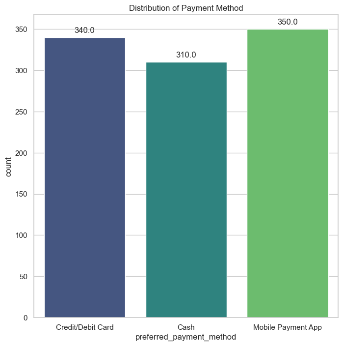

```python
# Set the style
sns.set(style="whitegrid")

# Create a count plot for 'preferred_payment_method' with annotations
plt.figure(figsize=(8, 8))
ax = sns.countplot(x='preferred_payment_method', data=df, palette='viridis')

# Annotate each bar with the count
for p in ax.patches:
    ax.annotate(f'{p.get_height()}', (p.get_x() + p.get_width() / 2., p.get_height()),
                ha='center', va='center', xytext=(0, 10), textcoords='offset points')

# Set plot title
plt.title('Distribution of Payment Method')

# Display the plot
plt.show()
```

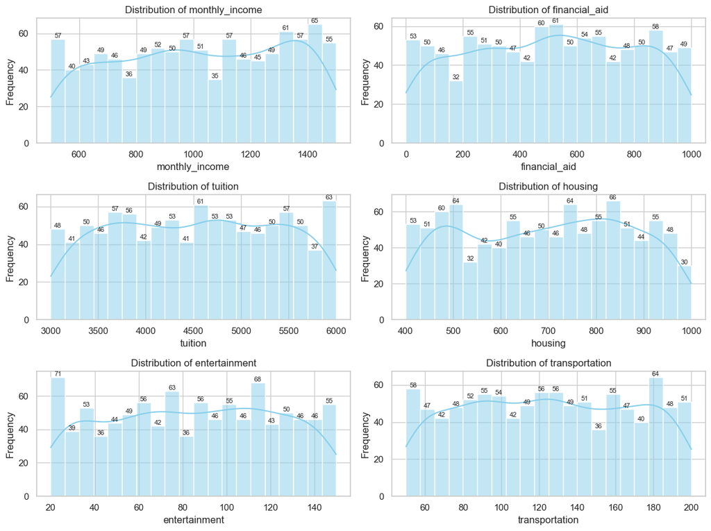

```python
# Select additional columns for histograms
selected_columns = ['monthly_income', 'financial_aid', 'tuition', 'housing', 'entertainment', 'transportation']

# Determine the number of rows and columns for subplots
num_rows = len(selected_columns) // 2 + len(selected_columns) % 2
num_cols = 2

# Set up subplots
fig, axes = plt.subplots(num_rows, num_cols, figsize=(12, 3 * num_rows))

# Flatten the axes array for easy iteration
axes = axes.flatten()

# Plot histograms for each selected column
for i, column in enumerate(selected_columns):
    sns.histplot(df[column], bins=20, kde=True, ax=axes[i], color='skyblue')

    # Add numbers on top of each bar
    for rect in axes[i].patches:
        height = rect.get_height()
        axes[i].text(rect.get_x() + rect.get_width() / 2, height, f'{int(height)}', ha='center', va='bottom', fontsize=8)

    axes[i].set_title(f'Distribution of {column}')
    axes[i].set_xlabel(column)
    axes[i].set_ylabel('Frequency')

# Adjust layout to prevent overlapping
plt.tight_layout()
plt.show()
```

What do you see here?

Tuition Distribution Across Majors and Academic Years

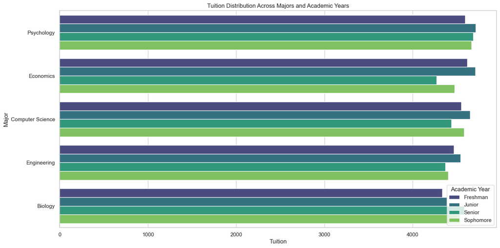

```python
# Select relevant columns
selected_columns = ['tuition', 'major', 'year_in_school']

# Filter the DataFrame for non-null values in the selected columns
filtered_df = df[selected_columns].dropna()

# Set up the bar plot
plt.figure(figsize=(16, 8))
sns.barplot(x='tuition', y='major', hue='year_in_school', data=filtered_df, ci=None, palette='viridis')

# Set plot title and labels
plt.title('Tuition Distribution Across Majors and Academic Years')
plt.xlabel('Tuition')
plt.ylabel('Major')

# Display the legend
plt.legend(title='Academic Year')

# Show the plot
plt.show()
```

The current observation reveals a common trend among four specializations – computer science, economics, engineering, and psychology. Specifically, for the third year students (juniors), expenses tend to peak, with one notable exception being the biology major, where the highest expenses occur during the final year (senior).

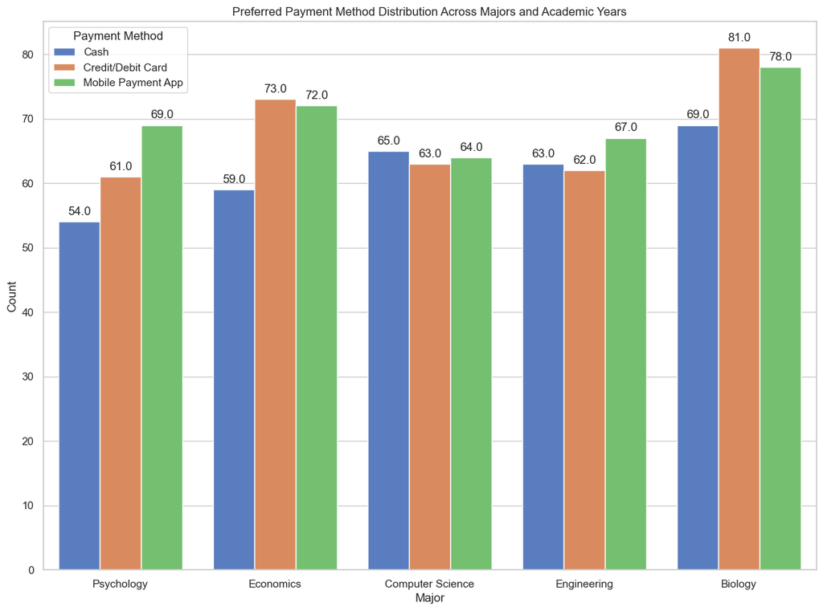

```python
# Select relevant columns
selected_columns = ['preferred_payment_method', 'major', 'year_in_school']

# Filter the DataFrame for non-null values in the selected columns
filtered_df = df[selected_columns].dropna()

# Set up the bar plot
plt.figure(figsize=(14, 10))
sns.countplot(x='major', hue='preferred_payment_method', data=filtered_df, palette='muted', hue_order=['Cash', 'Credit/Debit Card', 'Mobile Payment App'])

# Display the counts on top of the bars
for p in plt.gca().patches:
    plt.gca().annotate(f'{p.get_height()}', (p.get_x() + p.get_width() / 2., p.get_height()),
                       ha='center', va='center', xytext=(0, 10), textcoords='offset points')

# Set plot title and labels
plt.title('Preferred Payment Method Distribution Across Majors and Academic Years')
plt.xlabel('Major')
plt.ylabel('Count')

# Display the legend
plt.legend(title='Payment Method')

# Show the plot
plt.show()
```

Exploring the relationship between majors and preferred payment methods unveils interesting insights. Computer science and engineering students appear largely indifferent, exhibiting little variance in their payment choices. However, a stark contrast emerges among economics and biology students, where significant disparities exist in their preferences between electronic and cash payments. The intriguing question remains: What drives this marked divergence among majors?